# DS1000: Problem Set 3

Ananth Josyula

Due Date: 2022/09/25 @ 6PM CST

## Getting Set Up

If you haven’t already, create a folder for this course, and then a subfolder within for the second lecture `Topic5_DataWrangling`, and two additional subfolders within `code` and `data`.

Open `RStudio` and create a new RMarkDown file (`.Rmd`) by going to `File -> New File -> R Markdown...`. Change the title to `"DS1000: Problem Set 3"` and the author to your full name. Save this file as `[LAST NAME]_ps3.Rmd` to your `code` folder.

If you haven’t already, download the `game_summary.Rds` file from the course [github page](https://github.com/jbisbee1/DSCI1000/blob/main/Lectures/Topic5_UnivariateDescription/data/game_summary.Rds) and save it to your `data` folder.

## Question 1

Require the `tidyverse`, `tidymodels`, and `rsample` packages. Then load the `game_summary.Rds` data to `gms`.

```r
# INSERT CODE HERE
require(tidyverse)
require(tidymodels)
require(rsample)
gms<-readRDS("../data/game_summary.rds")
```

## Question 2 [2 points]

Which team had the most wins in 2017? Is it the same team that had the most wins in 2018? Which team had the most wins overall?

```r
# INSERT CODE HERE
gms %>% filter (yearSeason == 2017) %>% filter(isWin == TRUE) %>% group_by(nameTeam) %>% count(isWin) %>% arrange(-n)
```

```
## # A tibble: 30 × 3
## # Groups:   nameTeam [30]
##    nameTeam              isWin     n
##    <chr>                 <lgl> <int>
##  1 Golden State Warriors TRUE     67
##  2 San Antonio Spurs     TRUE     61
##  3 Houston Rockets       TRUE     55
##  4 Boston Celtics        TRUE     53
##  5 Cleveland Cavaliers   TRUE     51
##  6 LA Clippers           TRUE     51
##  7 Toronto Raptors       TRUE     51
##  8 Utah Jazz             TRUE     51
##  9 Washington Wizards    TRUE     49
## 10 Oklahoma City Thunder TRUE     47
## # … with 20 more rows
```

```r
gms %>% filter (yearSeason == 2018) %>% filter(isWin == TRUE) %>% group_by(nameTeam) %>% count(isWin) %>% arrange(-n)
```

```
## # A tibble: 30 × 3
## # Groups:   nameTeam [30]
##    nameTeam               isWin     n
##    <chr>                  <lgl> <int>
##  1 Houston Rockets        TRUE     65
##  2 Toronto Raptors        TRUE     59
##  3 Golden State Warriors  TRUE     58
##  4 Boston Celtics         TRUE     55
##  5 Philadelphia 76ers     TRUE     52
##  6 Cleveland Cavaliers    TRUE     50
##  7 Portland Trail Blazers TRUE     49
##  8 Indiana Pacers         TRUE     48
##  9 New Orleans Pelicans   TRUE     48
## 10 Oklahoma City Thunder  TRUE     48
## # … with 20 more rows
```

```r
gms %>% filter(isWin == TRUE) %>% group_by(nameTeam) %>% count(isWin) %>% arrange(-n)
```

```
## # A tibble: 30 × 3
## # Groups:   nameTeam [30]
##    nameTeam               isWin     n
##    <chr>                  <lgl> <int>
##  1 Golden State Warriors  TRUE    182
##  2 Houston Rockets        TRUE    173
##  3 Toronto Raptors        TRUE    168
##  4 Boston Celtics         TRUE    157
##  5 San Antonio Spurs      TRUE    156
##  6 Utah Jazz              TRUE    149
##  7 Milwaukee Bucks        TRUE    146
##  8 Oklahoma City Thunder  TRUE    144
##  9 Portland Trail Blazers TRUE    143
## 10 LA Clippers            TRUE    141
## # … with 20 more rows
```

```r
gms %>% filter(isWin == TRUE) %>% group_by(nameTeam) %>% count(isWin) %>% arrange(n)
```

```
## # A tibble: 30 × 3
## # Groups:   nameTeam [30]
##    nameTeam           isWin     n
##    <chr>              <lgl> <int>
##  1 Phoenix Suns       TRUE     64
##  2 New York Knicks    TRUE     77
##  3 Brooklyn Nets      TRUE     90
##  4 Chicago Bulls      TRUE     90
##  5 Dallas Mavericks   TRUE     90
##  6 Atlanta Hawks      TRUE     96
##  7 Orlando Magic      TRUE     96
##  8 Los Angeles Lakers TRUE     98
##  9 Memphis Grizzlies  TRUE     98
## 10 Sacramento Kings   TRUE     98
## # … with 20 more rows
```

> Golden State Warriors had the most wins in 2017 with 67. Houston Rockets had the most wins in 2018 with 65. Golden State Warriors had the most wins overall with 182.

## Question 3 [2 points]

Which team held the most wins-per-season overall? Which team held the least?

```r
# INSERT CODE HERE
gms %>% group_by(nameTeam, yearSeason) %>% filter(isWin == TRUE) %>% count(isWin == TRUE)%>% group_by(nameTeam) %>%
  summarise(meanWin = mean(n, na.rm=T))  %>% arrange(-meanWin)
```

```
## # A tibble: 30 × 2
##    nameTeam               meanWin
##    <chr>                    <dbl>
##  1 Golden State Warriors     60.7
##  2 Houston Rockets           57.7
##  3 Toronto Raptors           56
##  4 Boston Celtics            52.3
##  5 San Antonio Spurs         52
##  6 Utah Jazz                 49.7
##  7 Milwaukee Bucks           48.7
##  8 Oklahoma City Thunder     48
##  9 Portland Trail Blazers    47.7
## 10 LA Clippers               47
## # … with 20 more rows
```

```r
gms %>% group_by(nameTeam, yearSeason) %>% filter(isWin == TRUE) %>% count(isWin == TRUE)%>% group_by(nameTeam) %>%
  summarise(meanWin = mean(n, na.rm=T))  %>% arrange(meanWin)
```

```
## # A tibble: 30 × 2
##    nameTeam           meanWin
##    <chr>                <dbl>
##  1 Phoenix Suns          21.3
##  2 New York Knicks       25.7
##  3 Brooklyn Nets         30
##  4 Chicago Bulls         30
##  5 Dallas Mavericks      30
##  6 Atlanta Hawks         32
##  7 Orlando Magic         32
##  8 Los Angeles Lakers    32.7
##  9 Memphis Grizzlies     32.7
## 10 Sacramento Kings      32.7
## # … with 20 more rows
```

> Golden State Warriors had the most wins-per-season overall. Phoenix Suns had the least wins-per-season overall.

## Question 4 [3 points]

Is “home court advantage” real? (In other words, do teams win more games when they’re playing at home?) For which team is the “home court advantage” largest? For which team does the “home court advantage” matter least? Is there any team with a “home court disadvantage”? Extra Credit: Do you notice anything about the two teams for whom the “home court advantage” mattered least?

```r
# INSERT CODE HERE
gms %>%
  group_by(nameTeam, locationGame) %>%
  summarise(meanWin = mean(isWin, na.rm=T)) %>% spread(locationGame, meanWin)%>% mutate(diff = H-A) %>%
  arrange(-diff)
```

```
## # A tibble: 30 × 4
## # Groups:   nameTeam [30]
##    nameTeam                   A     H  diff
##    <chr>                  <dbl> <dbl> <dbl>
##  1 San Antonio Spurs      0.488 0.780 0.293
##  2 Minnesota Timberwolves 0.317 0.610 0.293
##  3 Denver Nuggets         0.431 0.707 0.276
##  4 Detroit Pistons        0.341 0.610 0.268
##  5 Indiana Pacers         0.431 0.691 0.260
##  6 Dallas Mavericks       0.244 0.488 0.244
##  7 Portland Trail Blazers 0.472 0.691 0.220
##  8 Cleveland Cavaliers    0.382 0.593 0.211
##  9 Washington Wizards     0.398 0.610 0.211
## 10 Charlotte Hornets      0.350 0.553 0.203
## # … with 20 more rows
```

```r
gms %>%
  group_by(nameTeam, locationGame) %>%
  summarise(meanWin = mean(isWin, na.rm=T)) %>% spread(locationGame, meanWin)%>% mutate(diff = H-A) %>%
  arrange(diff)
```

```
## # A tibble: 30 × 4
## # Groups:   nameTeam [30]
##    nameTeam                  A     H   diff
##    <chr>                 <dbl> <dbl>  <dbl>
##  1 Golden State Warriors 0.707 0.772 0.0650
##  2 Phoenix Suns          0.220 0.301 0.0813
##  3 Brooklyn Nets         0.317 0.415 0.0976
##  4 Chicago Bulls         0.317 0.415 0.0976
##  5 Sacramento Kings      0.350 0.447 0.0976
##  6 Miami Heat            0.455 0.553 0.0976
##  7 LA Clippers           0.520 0.626 0.106
##  8 Boston Celtics        0.585 0.691 0.106
##  9 New Orleans Pelicans  0.415 0.520 0.106
## 10 Atlanta Hawks         0.325 0.455 0.130
## # … with 20 more rows
```

> San Antonio Spurs and Minnesota Timberwolves had the largest “home court advantage” of 0.293. Meanwhile, Golden State Warriors had the smallest “home court advantage” of 0.0650. No team won more games away than at home meaning that no team had a “home court disadvantage”. Although Golden State Warriors had the smallest “home court advantage”, they also had the most wins-per-season overall. Meanwhile, Phoenix Suns had the second smallest “home court advantage” of 0.0813 and also had the least wins-per-season overall.

## Question 5 [2 points]

How confident are you that the home court advantage is real? Bootstrap sample 1,000 times with `size = 200`, and `set.seed(123)`.

```r
# INSERT CODE HERE
set.seed(123)
bsSeasons <- NULL

for(i in 1:1000) {
  bsSeasons <- gms %>%
    sample_n(size = 200, replace = T) %>% group_by(locationGame) %>% summarise(avgWin = mean(isWin)) %>% spread(locationGame, avgWin) %>% mutate(hca = H-A) %>% bind_rows(bsSeasons)
}

bsSeasons %>%
  mutate(hWins = ifelse(H>A, 1,0)) %>%
  summarise(mean(hWins))
```

```
## # A tibble: 1 × 1
##   `mean(hWins)`
##           <dbl>
## 1         0.989
```

> We are 98.9% certain that home court advantage is real because 989/1000 trials had a team’s home wins surpass its away wins.

## Question 6 [3 points]

Why does the home court advantage exist? Is it because of fewer turnovers at home? How certain are you of your conclusion? Again, draw your conclusion with bootstrapping and `set.seed(123)`.

```r
# INSERT CODE HERE
set.seed(123)
bs_tov <- NULL

for(i in 1:1000) {
  bs_tov <- gms %>%
    sample_n(size = 200,replace = T) %>% group_by(locationGame) %>% summarise(avgTov = mean(tov)) %>% spread(locationGame, avgTov) %>% mutate(hca = H-A) %>% bind_rows(bs_tov)
}

bs_tov %>%
  mutate(tHome = ifelse(H<A,1,0)) %>%
  summarise(mean(tHome))
```

```
## # A tibble: 1 × 1
##   `mean(tHome)`
##           <dbl>
## 1         0.557
```

> We are 55.7% certain that teams experience fewer turnovers at home than away. This could be because players are more comfrtable being cheered on than booed against and correspondingly experience fewer turnovers.

## Question 7 [2 points]

Plot the home and away distributions of average turnovers from Question 6. (HINT: save time with the `gather()` function from `tidyverse`.)

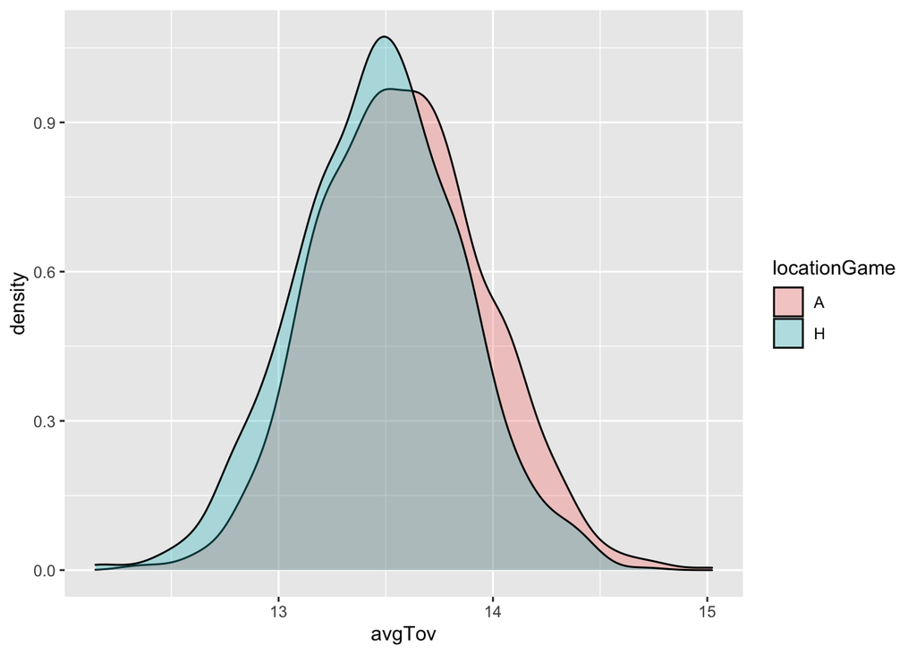

```r
# INSERT CODE HERE
bs_tov_plt <- NULL
for(i in 1:1000) {
  bs_tov_plt <- gms %>%
    sample_n(size = 200,replace = T) %>% group_by(locationGame) %>% summarise(avgTov = mean(tov)) %>% bind_rows(bs_tov_plt)
}

bs_tov_plt %>%
  ggplot(aes(x = avgTov,fill = locationGame)) +
  geom_density(alpha = .3)
```

## Question 8 [2 points]

Does your answer to question 6 change if you look only at 2017 data? What about 2019 data?

```r
# INSERT CODE HERE
set.seed(123)
bs_tov <- NULL
for(i in 1:1000) {
  bs_tov <- gms %>%
    sample_n(size = 200,replace = T) %>%
    filter(yearSeason == "2017") %>%
    group_by(locationGame) %>%
    summarise(avgTov = mean(tov)) %>%
    spread(locationGame, avgTov) %>%
    bind_rows(bs_tov)
}

bs_tov %>%
  mutate(tHome = ifelse(H<A, 1,0)) %>%
  summarise(mean(tHome))
```

```
## # A tibble: 1 × 1
##   `mean(tHome)`
##           <dbl>
## 1         0.547
```

```r
bs_tov <- NULL
for(i in 1:1000) {
  bs_tov <- gms %>%
    sample_n(size = 200,replace = T) %>%
    filter(yearSeason == "2019") %>%
    group_by(locationGame) %>%
    summarise(avgTov = mean(tov)) %>%
    spread(locationGame, avgTov) %>%
    bind_rows(bs_tov)
}

bs_tov %>%
  mutate(tHome = ifelse(H<A, 1,0)) %>%
  summarise(mean(tHome))
```

```
## # A tibble: 1 × 1
##   `mean(tHome)`
##           <dbl>
## 1         0.536
```

## Question 9 [2 points]

Plot both of these conclusions. Overall, would you claim that the home court advantage is driven primarily by turnovers?

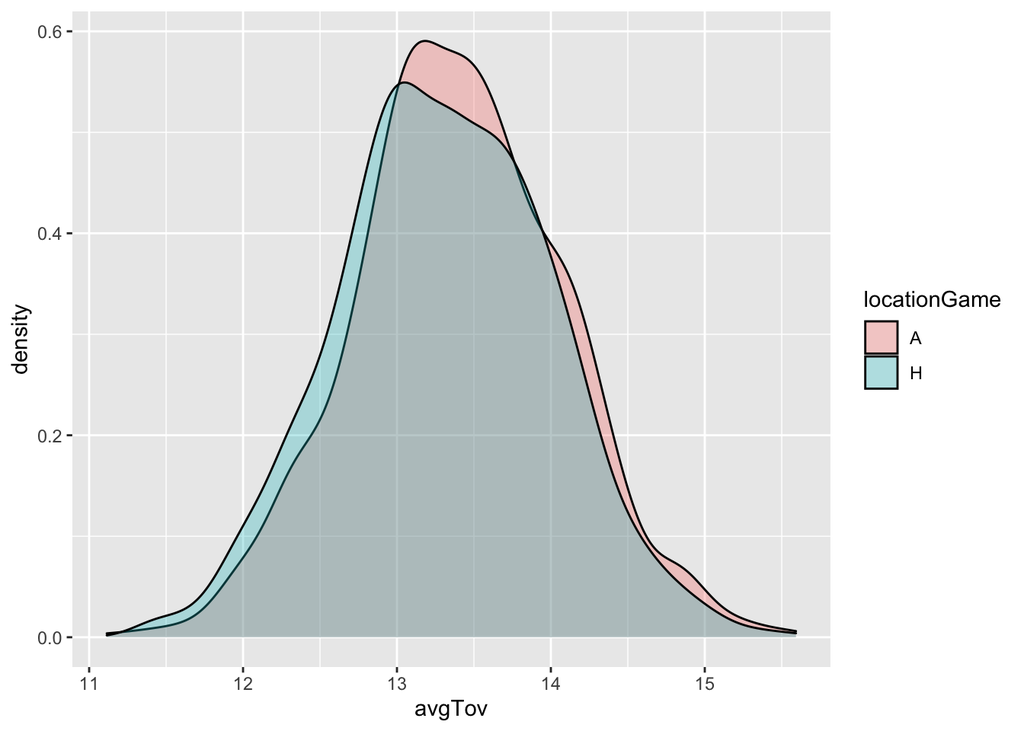

```r
# INSERT CODE HERE
set.seed(123)
bs_tov_plt <- NULL
for(i in 1:1000) {
  bs_tov_plt <- gms %>%
    sample_n(size = 200,replace = T) %>%
    filter(yearSeason == "2017") %>%
    group_by(locationGame) %>%
    summarise(avgTov = mean(tov)) %>%
    bind_rows(bs_tov_plt)
}

bs_tov_plt %>%
  ggplot(aes(x = avgTov,fill = locationGame)) +
  geom_density(alpha = .3)
```

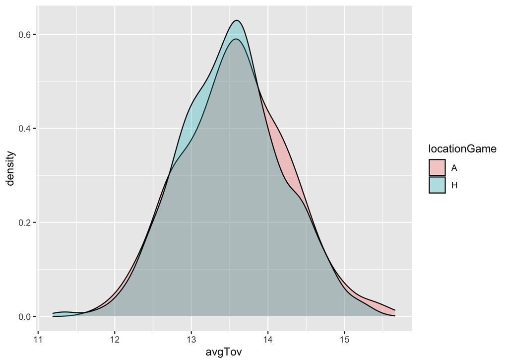

```r
bs_tov_plt <- NULL
for(i in 1:1000) {
  bs_tov_plt <- gms %>%
    sample_n(size = 200,replace = T) %>%
    filter(yearSeason == "2019") %>%
    group_by(locationGame) %>%
    summarise(avgTov = mean(tov)) %>%
    bind_rows(bs_tov_plt)
}

bs_tov_plt %>%
  ggplot(aes(x = avgTov,fill = locationGame)) +
  geom_density(alpha = .3)
```

> We cannot say that home court advantage is driven primarily by turnovers. In fact, as per the graphs there is an overwhelmingly large overlap between the turnovers of home and away games. However, in 2017 it is arguable that there was a slight correlation between lower turnovers and home games as well as greater turnovers and away games. Nevertheless, this is by no means the primariy reason for a home court advantage.

## Question 10 [2 points]

What about rebounds? Is there evidence to support the conclusion that NBA teams get more rebounds at home compared to when they are away? How confident are you in this conclusion? Plot the distribution to support your claim.

```r
# INSERT CODE HERE
set.seed(123)
bs_reb <- NULL
for(i in 1:1000) {
  bs_reb <- gms %>%
    sample_n(size = 200,replace = T) %>%
    filter(yearSeason == "2017") %>%
    group_by(locationGame) %>%
    summarise(avgReb = mean(treb)) %>%
    spread(locationGame, avgReb) %>%
    bind_rows(bs_reb)
}
bs_reb %>%
  mutate(rebDiff = ifelse(H>A, 1, 0)) %>%
  summarise(rebDiff = mean(rebDiff))%>%
  select(rebDiff)
```

```
## # A tibble: 1 × 1
##   rebDiff
##     <dbl>
## 1   0.764
```

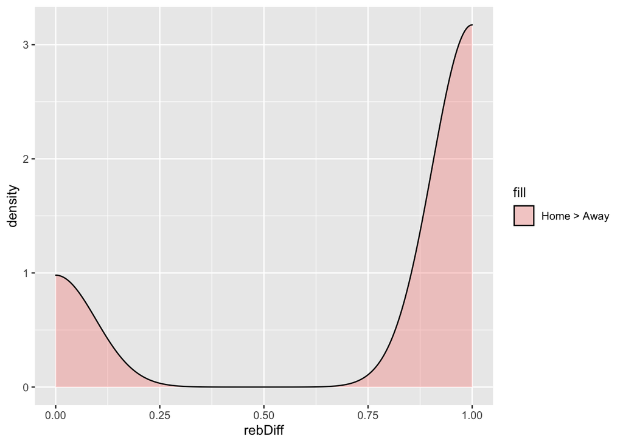

```r
bs_reb %>%
  mutate(rebDiff = ifelse(H>A, 1, 0)) %>%
  ggplot(aes(x = rebDiff,fill = 'Home > Away')) +
  geom_density(alpha = .3)
```

```r
bs_reb <- NULL
for(i in 1:1000) {
  bs_reb <- gms %>%
    sample_n(size = 200,replace = T) %>%
    filter(yearSeason == "2019") %>%
    group_by(locationGame) %>%
    summarise(avgReb = mean(treb)) %>%
    spread(locationGame, avgReb) %>%
    bind_rows(bs_reb)
}
bs_reb %>%
  mutate(rebDiff = ifelse(H>A, 1, 0)) %>%
  summarise(rebDiff = mean(rebDiff))%>%
  select(rebDiff)
```

```
## # A tibble: 1 × 1
##   rebDiff
##     <dbl>
## 1   0.799
```

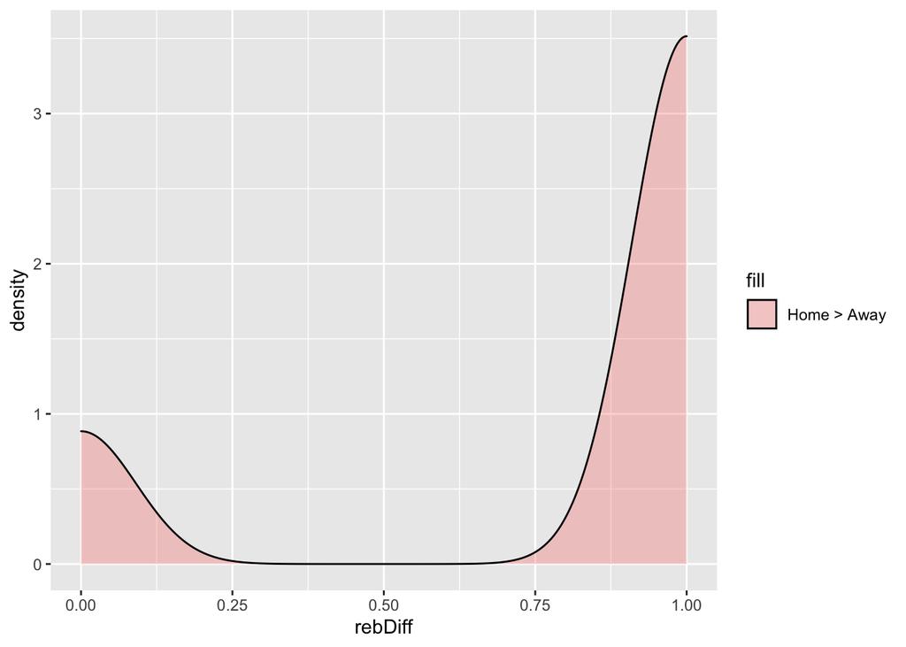

```r
bs_reb %>%
  mutate(rebDiff = ifelse(H>A, 1, 0)) %>%
  ggplot(aes(x = rebDiff,fill = 'Home > Away')) +
  geom_density(alpha = .3)
```

> Based on the graph, it appears that teams get more rebounds at home than away. Both in 2017 and in 2019, more home teams rebounded the ball more times than away teams.

## Question 11 [2 EC points]

Extra Credit: Is the conclusion that teams get more rebounds at home compared to when they are away more certain in 2017 than in 2019? How certain are you of this difference in certainties? (NB: be prepared to wait. This code takes a long time to run. Try reducing the number of bootstrapped samples to 100 to speed it up!)

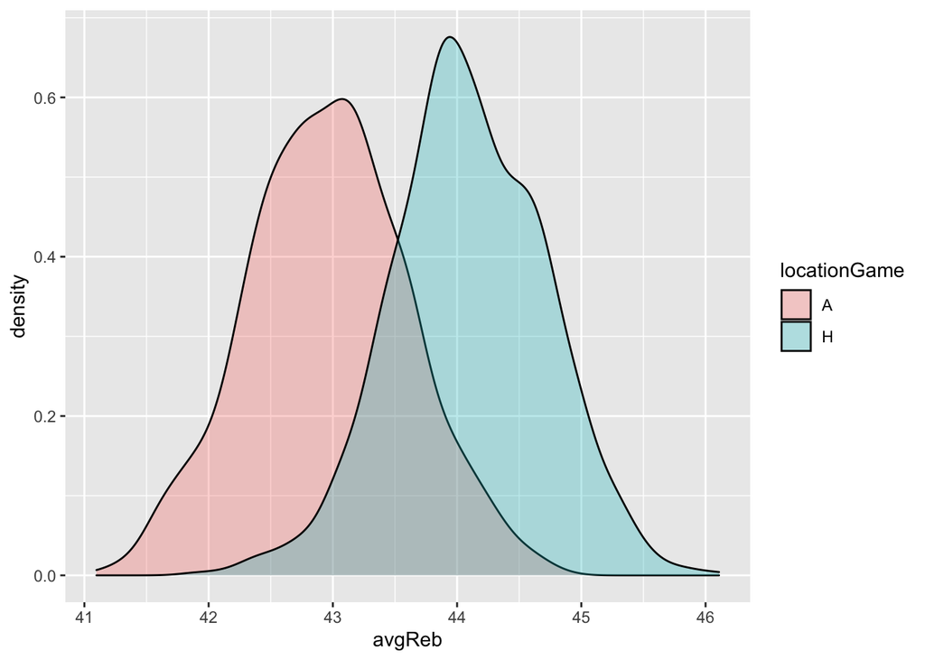

```r
# INSERT CODE HERE
set.seed(123)
bs_reb_plt <- NULL
for(i in 1:1000) {
  bs_reb_plt <- gms %>%
    filter(yearSeason == "2017")%>%
    sample_n(size = 200,replace = T) %>%
    group_by(locationGame) %>%
    summarise(avgReb = mean(treb)) %>%
    bind_rows(bs_reb_plt)
}

bs_reb_plt %>%
  ggplot(aes(x = avgReb,fill = locationGame)) +
  geom_density(alpha = .3)
```

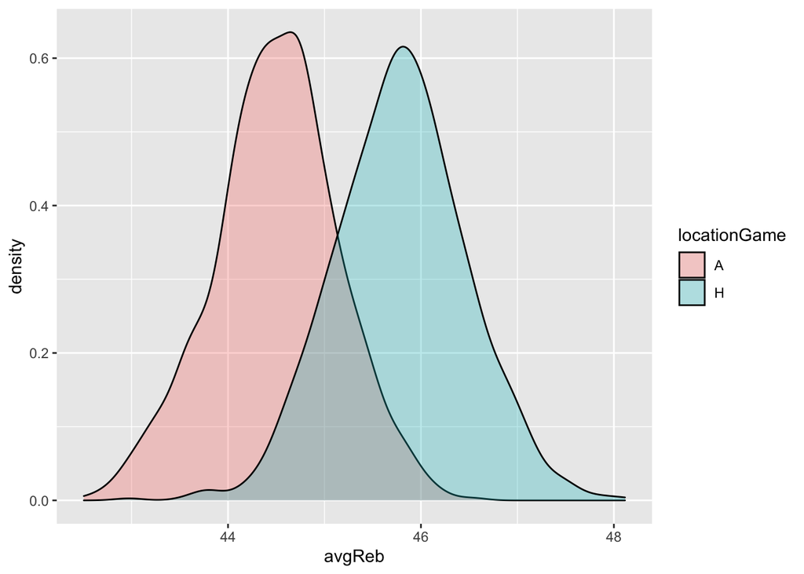

```r
bs_reb_plt <- NULL
for(i in 1:1000) {
  bs_reb_plt <- gms %>%
    filter(yearSeason == "2019") %>%
    sample_n(size = 200,replace = T) %>%
    group_by(locationGame) %>%
    summarise(avgReb = mean(treb)) %>%
    bind_rows(bs_reb_plt)
}

bs_reb_plt %>%
  ggplot(aes(x = avgReb,fill = locationGame)) +
  geom_density(alpha = .3)
```

> Both in 2017 and in 2019, more teams got more rebounds at home than away. Although this is not an extremely certain conclusion, the notciable difference in avgReb at the intersection of the Home and Away curves from around 43.5 to around 45 between 2017 and 2019 means we are reasonably certain.